# 📺 Pivot to Video

Mara Averick

2019-10-29

📺 OK, not *really*!

This is actually about `tidyr::pivot_*()` functions, which you can learn all about in the new tidyr version 1.0.0 [Pivoting vignette](https://tidyr.tidyverse.org/articles/pivot.html)!

But, I *will* be using some nifty TV-related data. So, I’m sticking with the name.

```r
library(tidyverse)
```

## 🍔 Bob’s Burgers: A Belcher Family survey

```r
sheet <- googlesheets::gs_title("bobs_burgers_survey_results")

bobs_ws <- googlesheets::gs_ws_ls(sheet)
```

```r
raw_dat <- sheet %>%
  googlesheets::gs_read(ws = glue::glue("{bobs_ws}"))
```

```
## Accessing worksheet titled 'Form Responses 1'.
```

```r
belcher_results <- tibble::rowid_to_column(raw_dat, "resp_id") %>%
  dplyr::rename("response" = `Members of the Belcher family with whom I identify (select all that apply)`) %>%
  dplyr::select(-Timestamp)

belcher_results
```

```
## # A tibble: 290 x 2
##    resp_id response
##      <int> <chr>
##  1       1 Linda, Tina, Louise
##  2       2 Bob, Gene
##  3       3 Bob, Tina, Gene
##  4       4 Bob, Linda, Tina, Gene, Louise
##  5       5 Bob
##  6       6 Louise
##  7       7 Bob
##  8       8 Bob
##  9       9 Bob, Gene
## 10      10 Bob, Linda, Tina
## # … with 280 more rows
```

Because I used a [Google Form](https://docs.google.com/forms/d/e/1FAIpQLScYLAkzDzEOWvXrn601Vt79S6DsKLkv12NUsqbo72j1fmapWA/viewform) to collect this data, I don’t have to worry about order of names, since they come out the same every time.

```r
agg_results <- belcher_results %>%
  dplyr::group_by(response) %>%
  dplyr::summarise(total = n()) %>%
  dplyr::arrange(desc(total))

agg_results
```

```
## # A tibble: 30 x 2
##    response                       total
##    <chr>                          <int>
##  1 Bob                               53
##  2 Tina                              31
##  3 Louise                            24
##  4 Bob, Tina                         22
##  5 Bob, Louise                       19
##  6 Bob, Tina, Louise                 18
##  7 Tina, Louise                      13
##  8 Bob, Linda, Tina, Gene, Louise    12
##  9 Bob, Tina, Gene                   10
## 10 Bob, Gene                          9
## # … with 20 more rows
```

### `tidyr::separate_rows()`

Let’s make them long with [`tidyr::separate_rows()`](https://tidyr.tidyverse.org/dev/reference/separate_rows.html). I’m also adding a numeric variable, `identify` (short for “character(s) with whom I identify”), and ensuring that respondent IDs don’t get erroneously treated as numeric, by converting them to characters.

```r
belcher_results <- belcher_results %>%
  tidyr::separate_rows(response) %>%
  dplyr::mutate(identify = 1,
                resp_id = as.character(resp_id))
```

```
## Note: Using an external vector in selections is brittle.
## ℹ If the data contains `vars` it will be selected instead.
## ℹ Use `all_of(vars)` instead of just `vars` to silence this message.
```

```r
head(belcher_results)
```

```
## # A tibble: 6 x 3
##   resp_id response identify
##   <chr>   <chr>       <dbl>
## 1 1       Linda           1
## 2 1       Tina            1
## 3 1       Louise          1
## 4 2       Bob             1
## 5 2       Gene            1
## 6 3       Bob             1
```

### `tidyr::pivot_wider()`

Now we’ll take one of the “new” tidyr verbs for a spin, [`pivot_wider()`](https://tidyr.tidyverse.org/dev/reference/pivot_wider.html). Rather than fill things out with a bunch of `NA`s, we’ll prepare our data to use with the `UpSetR` package by turning it into binaries, and ditch the respondent ID in the end.

```r
binary_tib <- belcher_results %>%
  tidyr::pivot_wider(
    names_from = response,
    values_from = identify,
    values_fill = list(identify = 0)
  ) %>%
  dplyr::select(-resp_id)

head(binary_tib)
```

```
## # A tibble: 6 x 5
##   Linda  Tina Louise   Bob  Gene
##   <dbl> <dbl>  <dbl> <dbl> <dbl>
## 1     1     1      1     0     0
## 2     0     0      0     1     1
## 3     0     1      0     1     1
## 4     1     1      1     1     1
## 5     0     0      0     1     0
## 6     0     0      1     0     0
```

### `UpSetR::upset()`

I *highly* recommend Paul Campbell’s [code-through](https://www.cultureofinsight.com/blog/2018/01/25/2018-01-25-visualising-twitter-follower-overlap/) using UpSetR, which gave me (among other things) the pro tip that `upset()` does *not* like tibbles (hence the `as.data.frame()` at the end).

```r
binary_df <- as.data.frame(binary_tib)
```

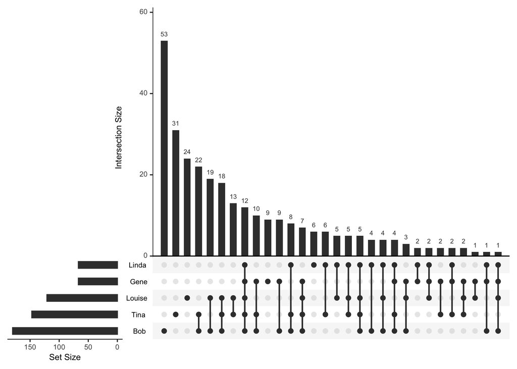

```r
UpSetR::upset(binary_df, nsets = 5, order.by = "freq")
```

## 🎬 I have seen this movie…

Let’s take a look at another dataset I collected with a quick survey, this one asking people whether they had or had not seen a given movie.

```r
sheet <- googlesheets::gs_title("seen_this_movie")
```

```
## Sheet successfully identified: "seen_this_movie"
```

```r
movie_ws <- googlesheets::gs_ws_ls(sheet)

raw_dat <- sheet %>%
  googlesheets::gs_read(ws = glue::glue("{movie_ws}"))
```

```
## Accessing worksheet titled 'Form Responses 1'.
```

First I’ll use [`tibble::rowid_to_column()`](https://tibble.tidyverse.org/reference/rownames.html) to keep track of which user said what (and, again, make sure those are stored as characters rather than numeric, so I don’t accidentally analyze it the wrong way).

I still don’t care about the timestamp, so I’ll get everything *but* that using `dplyr::select(-Timestamp)`.

The variable names here have a whole bunch of annoying characters (e.g. spaces, exclamation points). So, I’m going to use Sam Firke’s [janitor](https://sfirke.github.io/janitor/) package — specifically the [`janitor::clean_names()`](https://sfirke.github.io/janitor/reference/clean_names.html) function — to take care of some of the grunt work for me there.

I’m also going to rename `my_age_is` to `age`, just because it’s annoying.

```r
movie_results <- tibble::rowid_to_column(raw_dat, "resp_id") %>%
  dplyr::mutate(resp_id = as.character(resp_id)) %>%
  dplyr::select(-Timestamp) %>%
  janitor::clean_names() %>%
  dplyr::rename("age" = my_age_is)

head(movie_results)
```

```
## # A tibble: 6 x 14
##   resp_id airplane anchorman animal_house the_big_lebowski the_blues_broth…
##   <chr>   <lgl>    <lgl>     <lgl>        <lgl>            <lgl>
## 1 1       TRUE     TRUE      TRUE         FALSE            TRUE
## 2 2       FALSE    TRUE      TRUE         TRUE             FALSE
## 3 3       FALSE    FALSE     FALSE        TRUE             FALSE
## 4 4       FALSE    FALSE     FALSE        FALSE            FALSE
## 5 5       FALSE    TRUE      FALSE        FALSE            FALSE
## 6 6       FALSE    TRUE      FALSE        TRUE             TRUE
## # … with 8 more variables: borat <lgl>, bridesmaids <lgl>,
## #   office_space <lgl>, old_school <lgl>, this_is_spinal_tap <lgl>,
## #   tommy_boy <lgl>, superbad <lgl>, age <dbl>
```

Since this dataset is wide, let’s also take a gander at it using `glimpse()`:

```r
glimpse(movie_results)
```

```
## Observations: 158
## Variables: 14
## $ resp_id            <chr> "1", "2", "3", "4", "5", "6", "7", "8", "9", …
## $ airplane           <lgl> TRUE, FALSE, FALSE, FALSE, FALSE, FALSE, TRUE…
## $ anchorman          <lgl> TRUE, TRUE, FALSE, FALSE, TRUE, TRUE, TRUE, F…
## $ animal_house       <lgl> TRUE, TRUE, FALSE, FALSE, FALSE, FALSE, FALSE…
## $ the_big_lebowski   <lgl> FALSE, TRUE, TRUE, FALSE, FALSE, TRUE, TRUE, …
## $ the_blues_brothers <lgl> TRUE, FALSE, FALSE, FALSE, FALSE, TRUE, FALSE…
## $ borat              <lgl> FALSE, FALSE, TRUE, FALSE, FALSE, TRUE, FALSE…
## $ bridesmaids        <lgl> TRUE, TRUE, FALSE, FALSE, TRUE, FALSE, FALSE,…
## $ office_space       <lgl> FALSE, TRUE, FALSE, FALSE, FALSE, FALSE, FALS…
## $ old_school         <lgl> FALSE, TRUE, FALSE, FALSE, FALSE, FALSE, FALS…
## $ this_is_spinal_tap <lgl> FALSE, FALSE, FALSE, FALSE, FALSE, TRUE, FALS…
## $ tommy_boy          <lgl> FALSE, FALSE, FALSE, FALSE, FALSE, FALSE, FAL…
## $ superbad           <lgl> TRUE, TRUE, FALSE, FALSE, FALSE, TRUE, TRUE, …
## $ age                <dbl> 48, 31, 30, 20, 29, 28, 24, 42, 33, 34, 33, 3…
```

### [`tidyr::pivot_longer()`](https://tidyr.tidyverse.org/reference/pivot_longer.html)

Since I only want to elongate the movies, and all of those columns are logical, I’ll first select which columns I want by using `select_if()` and `is.logical()` as the predicate function.

```r
logicols <- select_if(movie_results, is.logical) %>%
  colnames()

movie_long <- movie_results %>%
  pivot_longer(
    cols = one_of(logicols),
    names_to = "movie",
    values_to = "seen"
  )

head(movie_long)
```

```
## # A tibble: 6 x 4
##   resp_id   age movie              seen
##   <chr>   <dbl> <chr>              <lgl>
## 1 1          48 airplane           TRUE
## 2 1          48 anchorman          TRUE
## 3 1          48 animal_house       TRUE
## 4 1          48 the_big_lebowski   FALSE
## 5 1          48 the_blues_brothers TRUE
## 6 1          48 borat              FALSE
```

Aside: A nice little trick for recoding `TRUE`/`FALSE` as `0` and `1`, just use `as.numeric()`.

```r
movie_bin <- movie_long %>%
  mutate(seen_num = as.numeric(seen))

movie_bin
```

```
## # A tibble: 1,896 x 5
##    resp_id   age movie              seen  seen_num
##    <chr>   <dbl> <chr>              <lgl>    <dbl>
##  1 1          48 airplane           TRUE         1
##  2 1          48 anchorman          TRUE         1
##  3 1          48 animal_house       TRUE         1
##  4 1          48 the_big_lebowski   FALSE        0
##  5 1          48 the_blues_brothers TRUE         1
##  6 1          48 borat              FALSE        0
##  7 1          48 bridesmaids        TRUE         1
##  8 1          48 office_space       FALSE        0
##  9 1          48 old_school         FALSE        0
## 10 1          48 this_is_spinal_tap FALSE        0
## # … with 1,886 more rows
```

```r
lil_seen <- movie_bin %>%
  select(resp_id, movie, seen_num)

movie_bin %>%
  group_by(movie) %>%
  summarise(pct_seen = sum(seen_num) / n()) %>%
  arrange(desc(pct_seen))
```

```
## # A tibble: 12 x 2
##    movie              pct_seen
##    <chr>                 <dbl>
##  1 the_big_lebowski      0.715
##  2 airplane              0.646
##  3 office_space          0.633
##  4 anchorman             0.627
##  5 superbad              0.608
##  6 bridesmaids           0.582
##  7 borat                 0.563
##  8 the_blues_brothers    0.563
##  9 animal_house          0.430
## 10 old_school            0.430
## 11 this_is_spinal_tap    0.367
## 12 tommy_boy             0.323
```

```r
library(corrr)

lil_seen_wide <- lil_seen %>%
  pivot_wider(names_from = movie, values_from = seen_num) %>%
  select(-resp_id)

correlate(lil_seen_wide) %>%
  fashion()
```

```
##
## Correlation method: 'pearson'
## Missing treated using: 'pairwise.complete.obs'
```

```
##               rowname airplane anchorman animal_house the_big_lebowski
## 1            airplane                .19          .43              .27
## 2           anchorman      .19                    .27              .27
## 3        animal_house      .43       .27                           .18
## 4    the_big_lebowski      .27       .27          .18
## 5  the_blues_brothers      .31       .06          .25              .38
## 6               borat     -.01       .32          .12              .38
## 7         bridesmaids      .15       .33          .32              .09
## 8        office_space      .34       .39          .42              .42
## 9          old_school      .16       .43          .51              .32
## 10 this_is_spinal_tap      .32       .18          .29              .19
## 11          tommy_boy      .31       .25          .52              .17
## 12           superbad      .16       .51          .36              .24
##    the_blues_brothers borat bridesmaids office_space old_school
## 1                 .31  -.01         .15          .34        .16
```

[output cut: 24 more lines]

```
##
## Correlation method: 'pearson'
## Missing treated using: 'pairwise.complete.obs'
```

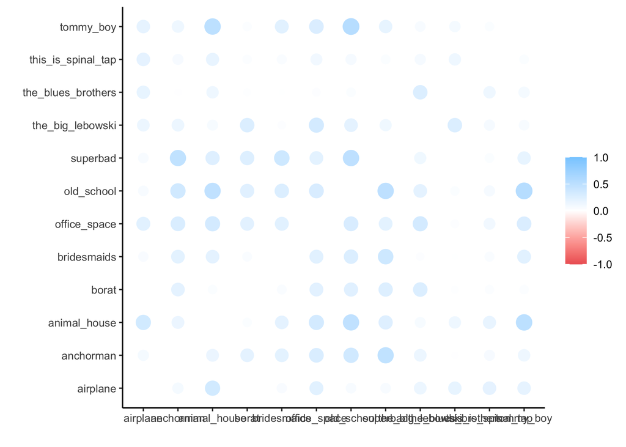

```r
correlate(lil_seen_wide) %>%
  rplot()
```

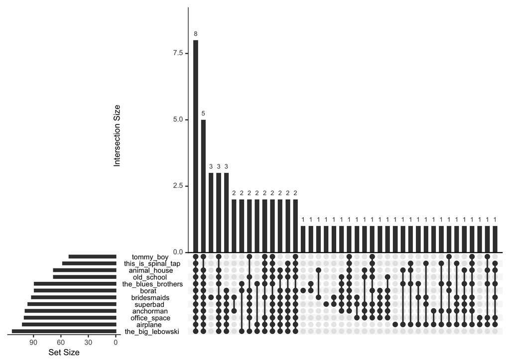

```r
lil_seen_wide <- as.data.frame(lil_seen_wide)
UpSetR::upset(lil_seen_wide, nsets = 13, order.by = "freq")
```

Let’s briefly pretend we’re looking at just three movies: Bridesmaids, Anchorman, and Airplane.

```r
three_movies <- c("airplane", "anchorman", "bridesmaids")
```

```r
movie_long %>%
  filter(movie %in% three_movies)
```

```
## # A tibble: 474 x 4
##    resp_id   age movie       seen
##    <chr>   <dbl> <chr>       <lgl>
##  1 1          48 airplane    TRUE
##  2 1          48 anchorman   TRUE
##  3 1          48 bridesmaids TRUE
##  4 2          31 airplane    FALSE
##  5 2          31 anchorman   TRUE
##  6 2          31 bridesmaids TRUE
##  7 3          30 airplane    FALSE
##  8 3          30 anchorman   FALSE
##  9 3          30 bridesmaids FALSE
## 10 4          20 airplane    FALSE
## # … with 464 more rows
```

For the wide version, we’ll add the respondent id and age to the list of variables we want to look at.

```r
vars_wanted <- c("resp_id", "age", three_movies)

movie_results %>%
  select(vars_wanted)
```

```
## Note: Using an external vector in selections is brittle.
## ℹ If the data contains `vars_wanted` it will be selected instead.
## ℹ Use `all_of(vars_wanted)` instead of just `vars_wanted` to silence this message.
```

```
## # A tibble: 158 x 5
##    resp_id   age airplane anchorman bridesmaids
##    <chr>   <dbl> <lgl>    <lgl>     <lgl>
##  1 1          48 TRUE     TRUE      TRUE
##  2 2          31 FALSE    TRUE      TRUE
##  3 3          30 FALSE    FALSE     FALSE
##  4 4          20 FALSE    FALSE     FALSE
##  5 5          29 FALSE    TRUE      TRUE
##  6 6          28 FALSE    TRUE      FALSE
##  7 7          24 TRUE     TRUE      FALSE
##  8 8          42 TRUE     FALSE     FALSE
##  9 9          33 TRUE     TRUE      TRUE
## 10 10         34 TRUE     TRUE      TRUE
## # … with 148 more rows
```

Note the change in “shape” of our data, though the contents remain the same:

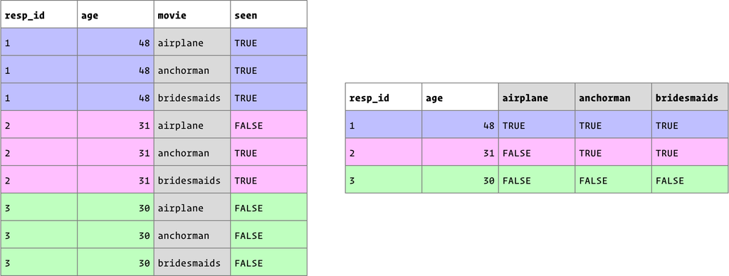